# Risk Factor Analysis

## Outcome Variable

**Outcome Variable:** stunted

## Predictor Variables

**Intervention Variable:** birthwtXexclfeed6

**Adjustment Set:**

- arm
- sex
- W_mage
- meducyrs
- feducyrs
- hhwealth_quart
- hfoodsec
- vagbrth
- W_nrooms
- W_nchldlt5
- brthmon
- W_parity
- impfloor
- impsan
- safeh20
- delta_W_mage
- delta_meducyrs
- delta_feducyrs
- delta_hhwealth_quart
- delta_hfoodsec
- delta_vagbrth
- delta_W_nrooms
- delta_W_nchldlt5
- delta_brthmon
- delta_W_parity
- delta_impfloor
- delta_impsan
- delta_safeh20

## Stratifying Variables

The analysis was stratified on these variable(s):

- agecat
- studyid
- country

## Data Summary

| agecat | studyid | country | birthwtXexclfeed6 | stunted | n_cell | n |
| --- | --- | --- | --- | --- | --- | --- |
| 24 months | ki0047075b-MAL-ED | BANGLADESH | Normal or high birthweight X EBF | 0 | 21 | 205 |
| 24 months | ki0047075b-MAL-ED | BANGLADESH | Normal or high birthweight X EBF | 1 | 20 | 205 |
| 24 months | ki0047075b-MAL-ED | BANGLADESH | Low birth weight X EBF | 0 | 5 | 205 |
| 24 months | ki0047075b-MAL-ED | BANGLADESH | Low birth weight X EBF | 1 | 7 | 205 |
| 24 months | ki0047075b-MAL-ED | BANGLADESH | Normal or high birthweight X No EBF | 0 | 74 | 205 |
| 24 months | ki0047075b-MAL-ED | BANGLADESH | Normal or high birthweight X No EBF | 1 | 47 | 205 |
| 24 months | ki0047075b-MAL-ED | BANGLADESH | Low birth weight X No EBF | 0 | 11 | 205 |
| 24 months | ki0047075b-MAL-ED | BANGLADESH | Low birth weight X No EBF | 1 | 20 | 205 |
| 24 months | ki0047075b-MAL-ED | BRAZIL | Normal or high birthweight X EBF | 0 | 13 | 169 |
| 24 months | ki0047075b-MAL-ED | BRAZIL | Normal or high birthweight X EBF | 1 | 0 | 169 |
| 24 months | ki0047075b-MAL-ED | BRAZIL | Low birth weight X EBF | 0 | 2 | 169 |
| 24 months | ki0047075b-MAL-ED | BRAZIL | Low birth weight X EBF | 1 | 0 | 169 |
| 24 months | ki0047075b-MAL-ED | BRAZIL | Normal or high birthweight X No EBF | 0 | 142 | 169 |
| 24 months | ki0047075b-MAL-ED | BRAZIL | Normal or high birthweight X No EBF | 1 | 6 | 169 |
| 24 months | ki0047075b-MAL-ED | BRAZIL | Low birth weight X No EBF | 0 | 6 | 169 |
| 24 months | ki0047075b-MAL-ED | BRAZIL | Low birth weight X No EBF | 1 | 0 | 169 |
| 24 months | ki0047075b-MAL-ED | INDIA | Normal or high birthweight X EBF | 0 | 1 | 217 |
| 24 months | ki0047075b-MAL-ED | INDIA | Normal or high birthweight X EBF | 1 | 4 | 217 |
| 24 months | ki0047075b-MAL-ED | INDIA | Low birth weight X EBF | 0 | 0 | 217 |
| 24 months | ki0047075b-MAL-ED | INDIA | Low birth weight X EBF | 1 | 0 | 217 |
| 24 months | ki0047075b-MAL-ED | INDIA | Normal or high birthweight X No EBF | 0 | 109 | 217 |
| 24 months | ki0047075b-MAL-ED | INDIA | Normal or high birthweight X No EBF | 1 | 69 | 217 |
| 24 months | ki0047075b-MAL-ED | INDIA | Low birth weight X No EBF | 0 | 17 | 217 |
| 24 months | ki0047075b-MAL-ED | INDIA | Low birth weight X No EBF | 1 | 17 | 217 |
| 24 months | ki0047075b-MAL-ED | NEPAL | Normal or high birthweight X EBF | 0 | 12 | 220 |
| 24 months | ki0047075b-MAL-ED | NEPAL | Normal or high birthweight X EBF | 1 | 2 | 220 |
| 24 months | ki0047075b-MAL-ED | NEPAL | Low birth weight X EBF | 0 | 0 | 220 |
| 24 months | ki0047075b-MAL-ED | NEPAL | Low birth weight X EBF | 1 | 0 | 220 |
| 24 months | ki0047075b-MAL-ED | NEPAL | Normal or high birthweight X No EBF | 0 | 152 | 220 |
| 24 months | ki0047075b-MAL-ED | NEPAL | Normal or high birthweight X No EBF | 1 | 34 | 220 |

[output cut: 194 more lines]

The following strata were considered:

- agecat: 24 months, studyid: ki0047075b-MAL-ED, country: BANGLADESH
- agecat: 24 months, studyid: ki0047075b-MAL-ED, country: BRAZIL
- agecat: 24 months, studyid: ki0047075b-MAL-ED, country: INDIA
- agecat: 24 months, studyid: ki0047075b-MAL-ED, country: NEPAL
- agecat: 24 months, studyid: ki0047075b-MAL-ED, country: PERU
- agecat: 24 months, studyid: ki0047075b-MAL-ED, country: SOUTH AFRICA
- agecat: 24 months, studyid: ki0047075b-MAL-ED, country: TANZANIA, UNITED REPUBLIC OF
- agecat: 24 months, studyid: ki1000108-CMC-V-BCS-2002, country: INDIA
- agecat: 24 months, studyid: ki1000108-IRC, country: INDIA
- agecat: 24 months, studyid: ki1017093b-PROVIDE, country: BANGLADESH
- agecat: 24 months, studyid: ki1101329-Keneba, country: GAMBIA
- agecat: 24 months, studyid: kiGH5241-JiVitA-3, country: BANGLADESH
- agecat: 24 months, studyid: kiGH5241-JiVitA-4, country: BANGLADESH
- agecat: 6 months, studyid: ki0047075b-MAL-ED, country: BANGLADESH
- agecat: 6 months, studyid: ki0047075b-MAL-ED, country: BRAZIL
- agecat: 6 months, studyid: ki0047075b-MAL-ED, country: INDIA
- agecat: 6 months, studyid: ki0047075b-MAL-ED, country: NEPAL
- agecat: 6 months, studyid: ki0047075b-MAL-ED, country: PERU
- agecat: 6 months, studyid: ki0047075b-MAL-ED, country: SOUTH AFRICA
- agecat: 6 months, studyid: ki0047075b-MAL-ED, country: TANZANIA, UNITED REPUBLIC OF
- agecat: 6 months, studyid: ki1000108-CMC-V-BCS-2002, country: INDIA
- agecat: 6 months, studyid: ki1000108-IRC, country: INDIA
- agecat: 6 months, studyid: ki1000109-EE, country: PAKISTAN
- agecat: 6 months, studyid: ki1000304b-SAS-CompFeed, country: INDIA
- agecat: 6 months, studyid: ki1017093b-PROVIDE, country: BANGLADESH
- agecat: 6 months, studyid: ki1101329-Keneba, country: GAMBIA
- agecat: 6 months, studyid: kiGH5241-JiVitA-3, country: BANGLADESH
- agecat: 6 months, studyid: kiGH5241-JiVitA-4, country: BANGLADESH

### Dropped Strata

Some strata were dropped due to rare outcomes:

- agecat: 24 months, studyid: ki0047075b-MAL-ED, country: BRAZIL
- agecat: 24 months, studyid: ki0047075b-MAL-ED, country: INDIA
- agecat: 24 months, studyid: ki0047075b-MAL-ED, country: NEPAL
- agecat: 24 months, studyid: ki0047075b-MAL-ED, country: PERU
- agecat: 24 months, studyid: ki0047075b-MAL-ED, country: SOUTH AFRICA
- agecat: 24 months, studyid: ki0047075b-MAL-ED, country: TANZANIA, UNITED REPUBLIC OF
- agecat: 24 months, studyid: ki1000108-CMC-V-BCS-2002, country: INDIA
- agecat: 24 months, studyid: ki1000108-IRC, country: INDIA
- agecat: 6 months, studyid: ki0047075b-MAL-ED, country: BRAZIL
- agecat: 6 months, studyid: ki0047075b-MAL-ED, country: INDIA
- agecat: 6 months, studyid: ki0047075b-MAL-ED, country: NEPAL
- agecat: 6 months, studyid: ki0047075b-MAL-ED, country: PERU
- agecat: 6 months, studyid: ki0047075b-MAL-ED, country: SOUTH AFRICA
- agecat: 6 months, studyid: ki0047075b-MAL-ED, country: TANZANIA, UNITED REPUBLIC OF
- agecat: 6 months, studyid: ki1000108-CMC-V-BCS-2002, country: INDIA
- agecat: 6 months, studyid: ki1000108-IRC, country: INDIA
- agecat: 6 months, studyid: ki1000304b-SAS-CompFeed, country: INDIA

## Methods Detail

We’re interested in the causal parameters $E[Y_a]$ for all values of $a \in \mathcal{A}$. These parameters represent the mean outcome if, possibly contrary to fact, we intervened to set all units to have $A=a$. Under the randomization and positivity assumptions, these are identified by the statistical parameters $\psi_a=E_W[E_{Y|A,W}(Y|A=a,W)]$. In addition, we’re interested in the mean of $Y$, $E[Y]$ under no intervention (the observed mean). We will estimate these parameters by using SuperLearner to fit the relevant likelihood factors – $E_{Y|A,W}(Y|A=a,W)$ and $p(A=a|W)$, and then updating our likelihood fit using a joint TMLE.

For unadjusted analyses ($W=\{\}$), initial likelihoods were estimated using Lrnr_glm to estimate the simple $E(Y|A)$ and Lrnr_mean to estimate $p(A)$. For adjusted analyses, a small library containing Lrnr_glmnet, Lrnr_xgboost, and Lrnr_mean was used.

Having estimated these parameters, we will then use the delta method to estimate relative risks and attributable risks relative to a prespecified baseline level of $A$.

# Results Detail

## Results Plots

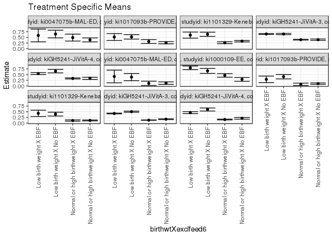

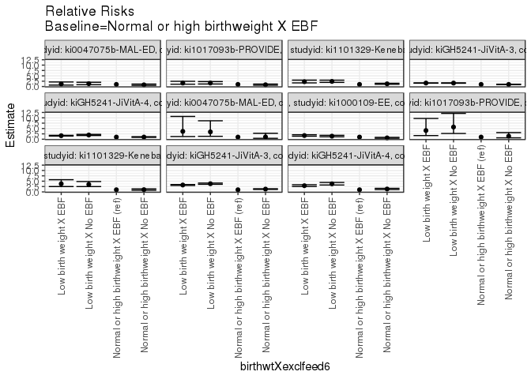

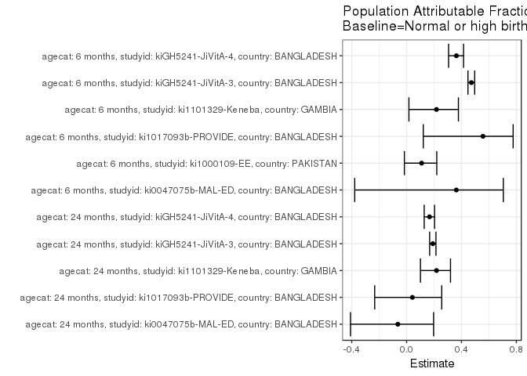

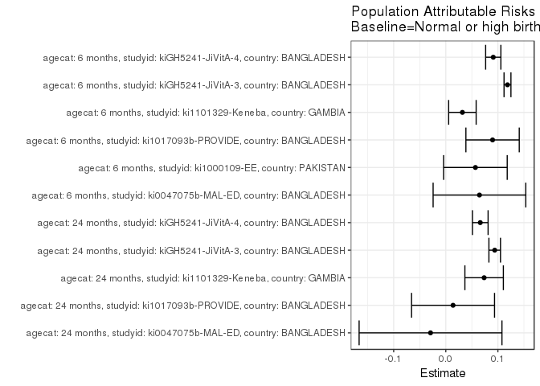

## Results Table

### Parameter: TSM

| agecat | studyid | country | intervention_level | baseline_level | estimate | ci_lower | ci_upper |
| --- | --- | --- | --- | --- | --- | --- | --- |
| 24 months | ki0047075b-MAL-ED | BANGLADESH | Normal or high birthweight X EBF | NA | 0.4878049 | 0.3344284 | 0.6411814 |
| 24 months | ki0047075b-MAL-ED | BANGLADESH | Low birth weight X EBF | NA | 0.5833333 | 0.3037108 | 0.8629558 |
| 24 months | ki0047075b-MAL-ED | BANGLADESH | Normal or high birthweight X No EBF | NA | 0.3884298 | 0.3013742 | 0.4754853 |
| 24 months | ki0047075b-MAL-ED | BANGLADESH | Low birth weight X No EBF | NA | 0.6451613 | 0.4763200 | 0.8140026 |
| 24 months | ki1017093b-PROVIDE | BANGLADESH | Normal or high birthweight X EBF | NA | 0.3153356 | 0.2275260 | 0.4031452 |
| 24 months | ki1017093b-PROVIDE | BANGLADESH | Low birth weight X EBF | NA | 0.5148461 | 0.3632935 | 0.6663986 |
| 24 months | ki1017093b-PROVIDE | BANGLADESH | Normal or high birthweight X No EBF | NA | 0.2624896 | 0.2151988 | 0.3097803 |
| 24 months | ki1017093b-PROVIDE | BANGLADESH | Low birth weight X No EBF | NA | 0.5205113 | 0.4230915 | 0.6179311 |
| 24 months | ki1101329-Keneba | GAMBIA | Normal or high birthweight X EBF | NA | 0.2638040 | 0.2209774 | 0.3066305 |
| 24 months | ki1101329-Keneba | GAMBIA | Low birth weight X EBF | NA | 0.5980964 | 0.4625819 | 0.7336109 |
| 24 months | ki1101329-Keneba | GAMBIA | Normal or high birthweight X No EBF | NA | 0.3318459 | 0.2993075 | 0.3643843 |
| 24 months | ki1101329-Keneba | GAMBIA | Low birth weight X No EBF | NA | 0.6354589 | 0.5442591 | 0.7266588 |
| 24 months | kiGH5241-JiVitA-3 | BANGLADESH | Normal or high birthweight X EBF | NA | 0.3969050 | 0.3800998 | 0.4137103 |
| 24 months | kiGH5241-JiVitA-3 | BANGLADESH | Low birth weight X EBF | NA | 0.6485278 | 0.6287732 | 0.6682823 |
| 24 months | kiGH5241-JiVitA-3 | BANGLADESH | Normal or high birthweight X No EBF | NA | 0.3968865 | 0.3663484 | 0.4274246 |
| 24 months | kiGH5241-JiVitA-3 | BANGLADESH | Low birth weight X No EBF | NA | 0.6455497 | 0.6160477 | 0.6750518 |
| 24 months | kiGH5241-JiVitA-4 | BANGLADESH | Normal or high birthweight X EBF | NA | 0.3303204 | 0.3071714 | 0.3534695 |
| 24 months | kiGH5241-JiVitA-4 | BANGLADESH | Low birth weight X EBF | NA | 0.5435852 | 0.5018295 | 0.5853409 |
| 24 months | kiGH5241-JiVitA-4 | BANGLADESH | Normal or high birthweight X No EBF | NA | 0.3345229 | 0.2874520 | 0.3815939 |
| 24 months | kiGH5241-JiVitA-4 | BANGLADESH | Low birth weight X No EBF | NA | 0.6512482 | 0.5741784 | 0.7283181 |
| 6 months | ki0047075b-MAL-ED | BANGLADESH | Normal or high birthweight X EBF | NA | 0.1136364 | 0.0196570 | 0.2076157 |
| 6 months | ki0047075b-MAL-ED | BANGLADESH | Low birth weight X EBF | NA | 0.4166667 | 0.1371186 | 0.6962147 |
| 6 months | ki0047075b-MAL-ED | BANGLADESH | Normal or high birthweight X No EBF | NA | 0.1231884 | 0.0682352 | 0.1781416 |
| 6 months | ki0047075b-MAL-ED | BANGLADESH | Low birth weight X No EBF | NA | 0.3888889 | 0.2292951 | 0.5484826 |
| 6 months | ki1000109-EE | PAKISTAN | Normal or high birthweight X EBF | NA | 0.4619486 | 0.3840261 | 0.5398711 |
| 6 months | ki1000109-EE | PAKISTAN | Low birth weight X EBF | NA | 0.7969716 | 0.7164894 | 0.8774538 |
| 6 months | ki1000109-EE | PAKISTAN | Normal or high birthweight X No EBF | NA | 0.2882907 | 0.2043246 | 0.3722568 |
| 6 months | ki1000109-EE | PAKISTAN | Low birth weight X No EBF | NA | 0.6624462 | 0.5528191 | 0.7720733 |
| 6 months | ki1017093b-PROVIDE | BANGLADESH | Normal or high birthweight X EBF | NA | 0.0714286 | 0.0203955 | 0.1224616 |
| 6 months | ki1017093b-PROVIDE | BANGLADESH | Low birth weight X EBF | NA | 0.2894737 | 0.1451546 | 0.4337927 |
| 6 months | ki1017093b-PROVIDE | BANGLADESH | Normal or high birthweight X No EBF | NA | 0.1011561 | 0.0693565 | 0.1329556 |
| 6 months | ki1017093b-PROVIDE | BANGLADESH | Low birth weight X No EBF | NA | 0.4059406 | 0.3100874 | 0.5017937 |
| 6 months | ki1101329-Keneba | GAMBIA | Normal or high birthweight X EBF | NA | 0.1145270 | 0.0848057 | 0.1442482 |
| 6 months | ki1101329-Keneba | GAMBIA | Low birth weight X EBF | NA | 0.4315587 | 0.2934786 | 0.5696388 |
| 6 months | ki1101329-Keneba | GAMBIA | Normal or high birthweight X No EBF | NA | 0.1199148 | 0.0999943 | 0.1398353 |
| 6 months | ki1101329-Keneba | GAMBIA | Low birth weight X No EBF | NA | 0.3969097 | 0.3127688 | 0.4810506 |
| 6 months | kiGH5241-JiVitA-3 | BANGLADESH | Normal or high birthweight X EBF | NA | 0.1322647 | 0.1241331 | 0.1403963 |
| 6 months | kiGH5241-JiVitA-3 | BANGLADESH | Low birth weight X EBF | NA | 0.4251945 | 0.4098359 | 0.4405532 |
| 6 months | kiGH5241-JiVitA-3 | BANGLADESH | Normal or high birthweight X No EBF | NA | 0.1728868 | 0.1559630 | 0.1898106 |
| 6 months | kiGH5241-JiVitA-3 | BANGLADESH | Low birth weight X No EBF | NA | 0.5044090 | 0.4792619 | 0.5295561 |
| 6 months | kiGH5241-JiVitA-4 | BANGLADESH | Normal or high birthweight X EBF | NA | 0.1598290 | 0.1418076 | 0.1778505 |
| 6 months | kiGH5241-JiVitA-4 | BANGLADESH | Low birth weight X EBF | NA | 0.4630236 | 0.4204158 | 0.5056314 |
| 6 months | kiGH5241-JiVitA-4 | BANGLADESH | Normal or high birthweight X No EBF | NA | 0.2146713 | 0.1751304 | 0.2542122 |
| 6 months | kiGH5241-JiVitA-4 | BANGLADESH | Low birth weight X No EBF | NA | 0.6013802 | 0.5340568 | 0.6687035 |

### Parameter: E(Y)

| agecat | studyid | country | intervention_level | baseline_level | estimate | ci_lower | ci_upper |
| --- | --- | --- | --- | --- | --- | --- | --- |
| 24 months | ki0047075b-MAL-ED | BANGLADESH | NA | NA | 0.4585366 | 0.3901604 | 0.5269127 |
| 24 months | ki1017093b-PROVIDE | BANGLADESH | NA | NA | 0.3292894 | 0.2909105 | 0.3676684 |
| 24 months | ki1101329-Keneba | GAMBIA | NA | NA | 0.3374046 | 0.3117905 | 0.3630186 |
| 24 months | kiGH5241-JiVitA-3 | BANGLADESH | NA | NA | 0.4907939 | 0.4775954 | 0.5039925 |
| 24 months | kiGH5241-JiVitA-4 | BANGLADESH | NA | NA | 0.3964951 | 0.3770031 | 0.4159871 |
| 6 months | ki0047075b-MAL-ED | BANGLADESH | NA | NA | 0.1782609 | 0.1286901 | 0.2278316 |
| 6 months | ki1000109-EE | PAKISTAN | NA | NA | 0.5188172 | 0.4679751 | 0.5696593 |
| 6 months | ki1017093b-PROVIDE | BANGLADESH | NA | NA | 0.1612350 | 0.1313580 | 0.1911120 |
| 6 months | ki1101329-Keneba | GAMBIA | NA | NA | 0.1464174 | 0.1291167 | 0.1637182 |
| 6 months | kiGH5241-JiVitA-3 | BANGLADESH | NA | NA | 0.2506905 | 0.2425258 | 0.2588553 |
| 6 months | kiGH5241-JiVitA-4 | BANGLADESH | NA | NA | 0.2509526 | 0.2340036 | 0.2679017 |

### Parameter: RR

| agecat | studyid | country | intervention_level | baseline_level | estimate | ci_lower | ci_upper |
| --- | --- | --- | --- | --- | --- | --- | --- |
| 24 months | ki0047075b-MAL-ED | BANGLADESH | Normal or high birthweight X EBF | Normal or high birthweight X EBF | 1.0000000 | 1.0000000 | 1.0000000 |
| 24 months | ki0047075b-MAL-ED | BANGLADESH | Low birth weight X EBF | Normal or high birthweight X EBF | 1.1958333 | 0.6740654 | 2.1214818 |
| 24 months | ki0047075b-MAL-ED | BANGLADESH | Normal or high birthweight X No EBF | Normal or high birthweight X EBF | 0.7962810 | 0.5412213 | 1.1715419 |
| 24 months | ki0047075b-MAL-ED | BANGLADESH | Low birth weight X No EBF | Normal or high birthweight X EBF | 1.3225806 | 0.8785350 | 1.9910643 |
| 24 months | ki1017093b-PROVIDE | BANGLADESH | Normal or high birthweight X EBF | Normal or high birthweight X EBF | 1.0000000 | 1.0000000 | 1.0000000 |
| 24 months | ki1017093b-PROVIDE | BANGLADESH | Low birth weight X EBF | Normal or high birthweight X EBF | 1.6326925 | 1.0882173 | 2.4495887 |
| 24 months | ki1017093b-PROVIDE | BANGLADESH | Normal or high birthweight X No EBF | Normal or high birthweight X EBF | 0.8324133 | 0.5974228 | 1.1598351 |
| 24 months | ki1017093b-PROVIDE | BANGLADESH | Low birth weight X No EBF | Normal or high birthweight X EBF | 1.6506583 | 1.1802213 | 2.3086117 |
| 24 months | ki1101329-Keneba | GAMBIA | Normal or high birthweight X EBF | Normal or high birthweight X EBF | 1.0000000 | 1.0000000 | 1.0000000 |
| 24 months | ki1101329-Keneba | GAMBIA | Low birth weight X EBF | Normal or high birthweight X EBF | 2.2672002 | 1.7156947 | 2.9959857 |
| 24 months | ki1101329-Keneba | GAMBIA | Normal or high birthweight X No EBF | Normal or high birthweight X EBF | 1.2579259 | 1.0408728 | 1.5202411 |
| 24 months | ki1101329-Keneba | GAMBIA | Low birth weight X No EBF | Normal or high birthweight X EBF | 2.4088300 | 1.9399894 | 2.9909762 |
| 24 months | kiGH5241-JiVitA-3 | BANGLADESH | Normal or high birthweight X EBF | Normal or high birthweight X EBF | 1.0000000 | 1.0000000 | 1.0000000 |
| 24 months | kiGH5241-JiVitA-3 | BANGLADESH | Low birth weight X EBF | Normal or high birthweight X EBF | 1.6339620 | 1.5556238 | 1.7162451 |
| 24 months | kiGH5241-JiVitA-3 | BANGLADESH | Normal or high birthweight X No EBF | Normal or high birthweight X EBF | 0.9999534 | 0.9178693 | 1.0893782 |
| 24 months | kiGH5241-JiVitA-3 | BANGLADESH | Low birth weight X No EBF | Normal or high birthweight X EBF | 1.6264589 | 1.5306976 | 1.7282111 |
| 24 months | kiGH5241-JiVitA-4 | BANGLADESH | Normal or high birthweight X EBF | Normal or high birthweight X EBF | 1.0000000 | 1.0000000 | 1.0000000 |
| 24 months | kiGH5241-JiVitA-4 | BANGLADESH | Low birth weight X EBF | Normal or high birthweight X EBF | 1.6456300 | 1.4837508 | 1.8251705 |
| 24 months | kiGH5241-JiVitA-4 | BANGLADESH | Normal or high birthweight X No EBF | Normal or high birthweight X EBF | 1.0127225 | 0.8717317 | 1.1765168 |
| 24 months | kiGH5241-JiVitA-4 | BANGLADESH | Low birth weight X No EBF | Normal or high birthweight X EBF | 1.9715653 | 1.7222226 | 2.2570076 |
| 6 months | ki0047075b-MAL-ED | BANGLADESH | Normal or high birthweight X EBF | Normal or high birthweight X EBF | 1.0000000 | 1.0000000 | 1.0000000 |
| 6 months | ki0047075b-MAL-ED | BANGLADESH | Low birth weight X EBF | Normal or high birthweight X EBF | 3.6666667 | 1.2640841 | 10.6357199 |
| 6 months | ki0047075b-MAL-ED | BANGLADESH | Normal or high birthweight X No EBF | Normal or high birthweight X EBF | 1.0840580 | 0.4236083 | 2.7742181 |
| 6 months | ki0047075b-MAL-ED | BANGLADESH | Low birth weight X No EBF | Normal or high birthweight X EBF | 3.4222222 | 1.3594073 | 8.6152291 |
| 6 months | ki1000109-EE | PAKISTAN | Normal or high birthweight X EBF | Normal or high birthweight X EBF | 1.0000000 | 1.0000000 | 1.0000000 |
| 6 months | ki1000109-EE | PAKISTAN | Low birth weight X EBF | Normal or high birthweight X EBF | 1.7252385 | 1.4177684 | 2.0993894 |
| 6 months | ki1000109-EE | PAKISTAN | Normal or high birthweight X No EBF | Normal or high birthweight X EBF | 0.6240753 | 0.4465550 | 0.8721657 |
| 6 months | ki1000109-EE | PAKISTAN | Low birth weight X No EBF | Normal or high birthweight X EBF | 1.4340257 | 1.1325285 | 1.8157864 |
| 6 months | ki1017093b-PROVIDE | BANGLADESH | Normal or high birthweight X EBF | Normal or high birthweight X EBF | 1.0000000 | 1.0000000 | 1.0000000 |
| 6 months | ki1017093b-PROVIDE | BANGLADESH | Low birth weight X EBF | Normal or high birthweight X EBF | 4.0526316 | 1.6957945 | 9.6850311 |
| 6 months | ki1017093b-PROVIDE | BANGLADESH | Normal or high birthweight X No EBF | Normal or high birthweight X EBF | 1.4161850 | 0.6488218 | 3.0911105 |
| 6 months | ki1017093b-PROVIDE | BANGLADESH | Low birth weight X No EBF | Normal or high birthweight X EBF | 5.6831683 | 2.6779138 | 12.0610314 |
| 6 months | ki1101329-Keneba | GAMBIA | Normal or high birthweight X EBF | Normal or high birthweight X EBF | 1.0000000 | 1.0000000 | 1.0000000 |
| 6 months | ki1101329-Keneba | GAMBIA | Low birth weight X EBF | Normal or high birthweight X EBF | 3.7681846 | 2.4956998 | 5.6894724 |
| 6 months | ki1101329-Keneba | GAMBIA | Normal or high birthweight X No EBF | Normal or high birthweight X EBF | 1.0470442 | 0.7696773 | 1.4243653 |
| 6 months | ki1101329-Keneba | GAMBIA | Low birth weight X No EBF | Normal or high birthweight X EBF | 3.4656444 | 2.4795848 | 4.8438317 |
| 6 months | kiGH5241-JiVitA-3 | BANGLADESH | Normal or high birthweight X EBF | Normal or high birthweight X EBF | 1.0000000 | 1.0000000 | 1.0000000 |
| 6 months | kiGH5241-JiVitA-3 | BANGLADESH | Low birth weight X EBF | Normal or high birthweight X EBF | 3.2147246 | 3.0074124 | 3.4363276 |
| 6 months | kiGH5241-JiVitA-3 | BANGLADESH | Normal or high birthweight X No EBF | Normal or high birthweight X EBF | 1.3071274 | 1.1685942 | 1.4620832 |
| 6 months | kiGH5241-JiVitA-3 | BANGLADESH | Low birth weight X No EBF | Normal or high birthweight X EBF | 3.8136333 | 3.5338118 | 4.1156122 |
| 6 months | kiGH5241-JiVitA-4 | BANGLADESH | Normal or high birthweight X EBF | Normal or high birthweight X EBF | 1.0000000 | 1.0000000 | 1.0000000 |
| 6 months | kiGH5241-JiVitA-4 | BANGLADESH | Low birth weight X EBF | Normal or high birthweight X EBF | 2.8969931 | 2.5034900 | 3.3523476 |
| 6 months | kiGH5241-JiVitA-4 | BANGLADESH | Normal or high birthweight X No EBF | Normal or high birthweight X EBF | 1.3431309 | 1.0893458 | 1.6560405 |
| 6 months | kiGH5241-JiVitA-4 | BANGLADESH | Low birth weight X No EBF | Normal or high birthweight X EBF | 3.7626469 | 3.2155083 | 4.4028845 |

### Parameter: PAR

| agecat | studyid | country | intervention_level | baseline_level | estimate | ci_lower | ci_upper |
| --- | --- | --- | --- | --- | --- | --- | --- |
| 24 months | ki0047075b-MAL-ED | BANGLADESH | Normal or high birthweight X EBF | NA | -0.0292683 | -0.1663446 | 0.1078080 |
| 24 months | ki1017093b-PROVIDE | BANGLADESH | Normal or high birthweight X EBF | NA | 0.0139538 | -0.0656761 | 0.0935838 |
| 24 months | ki1101329-Keneba | GAMBIA | Normal or high birthweight X EBF | NA | 0.0736006 | 0.0366777 | 0.1105235 |
| 24 months | kiGH5241-JiVitA-3 | BANGLADESH | Normal or high birthweight X EBF | NA | 0.0938889 | 0.0827706 | 0.1050072 |
| 24 months | kiGH5241-JiVitA-4 | BANGLADESH | Normal or high birthweight X EBF | NA | 0.0661747 | 0.0511539 | 0.0811955 |
| 6 months | ki0047075b-MAL-ED | BANGLADESH | Normal or high birthweight X EBF | NA | 0.0646245 | -0.0243144 | 0.1535634 |
| 6 months | ki1000109-EE | PAKISTAN | Normal or high birthweight X EBF | NA | 0.0568686 | -0.0041747 | 0.1179118 |
| 6 months | ki1017093b-PROVIDE | BANGLADESH | Normal or high birthweight X EBF | NA | 0.0898064 | 0.0386065 | 0.1410064 |
| 6 months | ki1101329-Keneba | GAMBIA | Normal or high birthweight X EBF | NA | 0.0318905 | 0.0055045 | 0.0582765 |
| 6 months | kiGH5241-JiVitA-3 | BANGLADESH | Normal or high birthweight X EBF | NA | 0.1184258 | 0.1118047 | 0.1250470 |
| 6 months | kiGH5241-JiVitA-4 | BANGLADESH | Normal or high birthweight X EBF | NA | 0.0911236 | 0.0765075 | 0.1057398 |

### Parameter: PAF

| agecat | studyid | country | intervention_level | baseline_level | estimate | ci_lower | ci_upper |
| --- | --- | --- | --- | --- | --- | --- | --- |
| 24 months | ki0047075b-MAL-ED | BANGLADESH | Normal or high birthweight X EBF | NA | -0.0638298 | -0.4091631 | 0.1968752 |
| 24 months | ki1017093b-PROVIDE | BANGLADESH | Normal or high birthweight X EBF | NA | 0.0423756 | -0.2326795 | 0.2560560 |
| 24 months | ki1101329-Keneba | GAMBIA | Normal or high birthweight X EBF | NA | 0.2181375 | 0.1011020 | 0.3199352 |
| 24 months | kiGH5241-JiVitA-3 | BANGLADESH | Normal or high birthweight X EBF | NA | 0.1913001 | 0.1680052 | 0.2139427 |
| 24 months | kiGH5241-JiVitA-4 | BANGLADESH | Normal or high birthweight X EBF | NA | 0.1668991 | 0.1282326 | 0.2038505 |
| 6 months | ki0047075b-MAL-ED | BANGLADESH | Normal or high birthweight X EBF | NA | 0.3625277 | -0.3781932 | 0.7051423 |
| 6 months | ki1000109-EE | PAKISTAN | Normal or high birthweight X EBF | NA | 0.1096120 | -0.0162614 | 0.2198948 |
| 6 months | ki1017093b-PROVIDE | BANGLADESH | Normal or high birthweight X EBF | NA | 0.5569909 | 0.1214644 | 0.7766089 |
| 6 months | ki1101329-Keneba | GAMBIA | Normal or high birthweight X EBF | NA | 0.2178053 | 0.0168173 | 0.3777061 |
| 6 months | kiGH5241-JiVitA-3 | BANGLADESH | Normal or high birthweight X EBF | NA | 0.4723985 | 0.4473112 | 0.4963471 |
| 6 months | kiGH5241-JiVitA-4 | BANGLADESH | Normal or high birthweight X EBF | NA | 0.3631108 | 0.3061324 | 0.4154104 |